# Chapter 5: Dimensionality reduction techniques

In this chapter, we learn the basics of two data science based ways of reducing the dimensions. The key method is principal component analysis (PCA), which reduces any number of measured (continuous) and correlated variables into a few uncorrelated components that collect together as much variance as possible from the original variables. The most important components can be then used for various purposes, e.g., drawing scatterplots and other fancy graphs that would be quite impossible to achieve with the original variables and too many dimensions.

> **Step 1.** Loading and checking the data.

The `human` data originates from the United Nations Development Programme.The Human Development Index (HDI) is a summary measure of average achievement in key dimensions of human development: a long and healthy life, being knowledgeable and have a decent standard of living. The HDI is the geometric mean of normalized indices for each of the three dimensions. The data contains 155 observations and 8 variables with the country as the `rolenames`. Detailed explanation of the variables can be found [here](http://hdr.undp.org/en/content/human-development-index-hdi). All the variables are either numeric or integerial (`dni` was changed from factor variable to numeric variable).

```r
human <- read.table("Data/human.txt")
human <- within(human, {
  gni <- as.character(gni)
})
human <- within(human, {
  gni <- as.numeric(sub(",", "", gni, fixed = TRUE))
})
str(human)
```

```
## 'data.frame':    155 obs. of  8 variables:
##  $ eduRatio  : num  1.007 0.997 0.983 0.989 0.969 ...
##  $ labRatio  : num  0.891 0.819 0.825 0.884 0.829 ...
##  $ lifebirth : num  81.6 82.4 83 80.2 81.6 80.9 80.9 79.1 82 81.8 ...
##  $ edutime   : num  17.5 20.2 15.8 18.7 17.9 16.5 18.6 16.5 15.9 19.2 ...
##  $ gni       : num  64992 42261 56431 44025 45435 ...
##  $ mortalityM: int  4 6 6 5 6 7 9 28 11 8 ...
##  $ teenbirth : num  7.8 12.1 1.9 5.1 6.2 3.8 8.2 31 14.5 25.3 ...
##  $ ParF      : num  39.6 30.5 28.5 38 36.9 36.9 19.9 19.4 28.2 31.4 ...
```

```r
dim(human)
```

```
## [1] 155   8
```

A graphical overview, a summary and a correlation matrix were plotted for `human` data and shown below. You can find the distribution of the data in the summary table with some statistical measures.

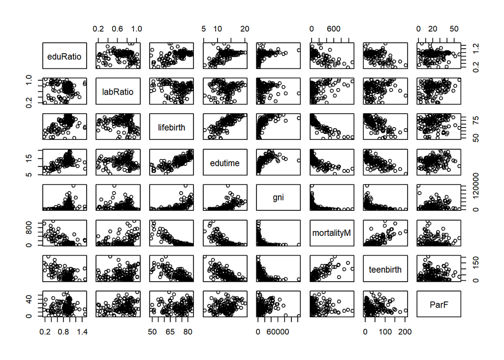

```r
library(corrplot)
library(tidyverse)
library(dplyr)
library(tidyr)
library(GGally)
library(ggplot2)
pairs(human)
```

```r
summary(human)
```

```
##     eduRatio         labRatio        lifebirth        edutime
##  Min.   :0.1717   Min.   :0.1857   Min.   :49.00   Min.   : 5.40
##  1st Qu.:0.7264   1st Qu.:0.5984   1st Qu.:66.30   1st Qu.:11.25
##  Median :0.9375   Median :0.7535   Median :74.20   Median :13.50
##  Mean   :0.8529   Mean   :0.7074   Mean   :71.65   Mean   :13.18
##  3rd Qu.:0.9968   3rd Qu.:0.8535   3rd Qu.:77.25   3rd Qu.:15.20
##  Max.   :1.4967   Max.   :1.0380   Max.   :83.50   Max.   :20.20
##       gni           mortalityM       teenbirth           ParF
##  Min.   :   581   Min.   :   1.0   Min.   :  0.60   Min.   : 0.00
##  1st Qu.:  4198   1st Qu.:  11.5   1st Qu.: 12.65   1st Qu.:12.40
##  Median : 12040   Median :  49.0   Median : 33.60   Median :19.30
##  Mean   : 17628   Mean   : 149.1   Mean   : 47.16   Mean   :20.91
##  3rd Qu.: 24512   3rd Qu.: 190.0   3rd Qu.: 71.95   3rd Qu.:27.95
##  Max.   :123124   Max.   :1100.0   Max.   :204.80   Max.   :57.50
```

The correlation matrix shown here are in the form of a heat-map. Dark red color meaning negatively correlated, dark blue color meaning positively correlated, and white meaning no correlation. You can easily spot certain pairs that have stronger correlations from the graph.

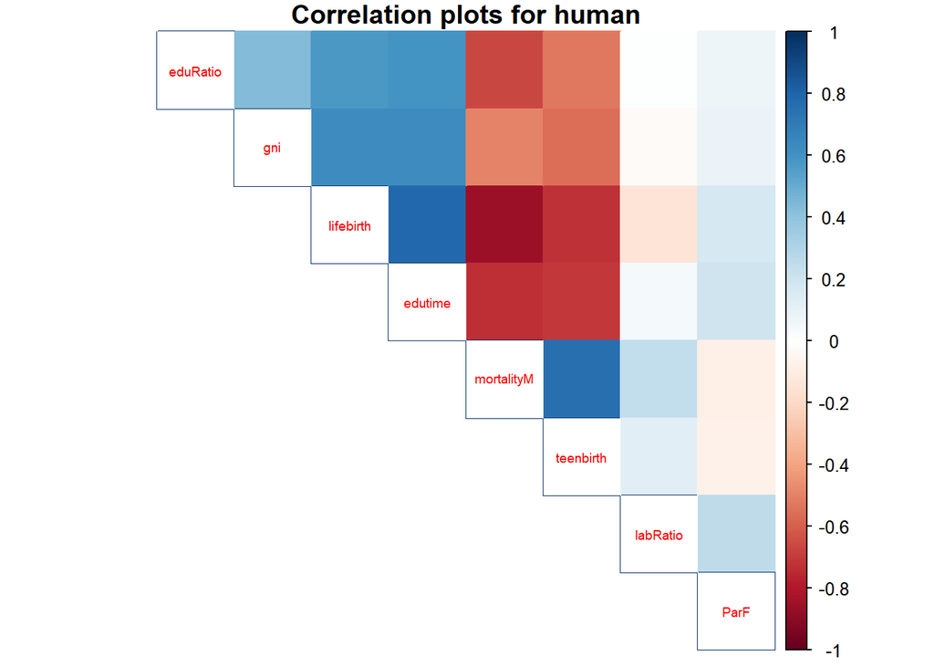

```r
cor(human) %>% corrplot(method="color", order="hclust", type = "upper", cl.pos = "r", tl.pos = "d", tl.cex = 0.6, title = "Correlation plots for human", mar=c(0,0,1,0))
```

> **Step 2.** Perform principal component analysis (PCA) on the not standardized human data.

The requested PCA was performed on the non-standardized human data.

```r
pca_human <- prcomp(human)
s <- summary(pca_human)
s
```

```
## Importance of components:
##                              PC1      PC2   PC3   PC4   PC5   PC6    PC7
## Standard deviation     1.854e+04 185.5219 25.19 11.45 3.766 1.566 0.1912
## Proportion of Variance 9.999e-01   0.0001  0.00  0.00 0.000 0.000 0.0000
## Cumulative Proportion  9.999e-01   1.0000  1.00  1.00 1.000 1.000 1.0000
##                           PC8
## Standard deviation     0.1591
## Proportion of Variance 0.0000
## Cumulative Proportion  1.0000
```

We can see from the summary of the PCA that the `gni` variable captured 100% of the variability. This is of course not correct. Why? Simply because the values are too huge compared to all other variables. Here the biplot is drawn and you can see that the arrow of `gni` is parallel to the PC1, meaning that they are basially the same determining factor during the analysis.

```r
pca_pr <- round(100*s$importance[2, ], digits = 1)
pca_pr
```

```
## PC1 PC2 PC3 PC4 PC5 PC6 PC7 PC8
## 100   0   0   0   0   0   0   0
```

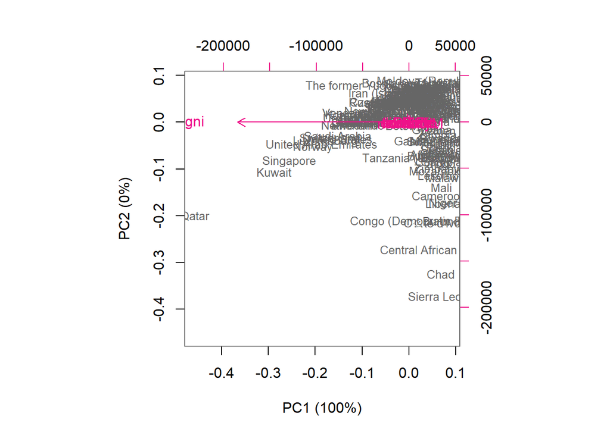

```r
pc_lab <- paste0(names(pca_pr), " (", pca_pr, "%)")
biplot(pca_human, cex = c(0.8, 1), col = c("grey40", "deeppink2"), xlab = pc_lab[1], ylab = pc_lab[2])
```

> **Step 3.** Perform principal component analysis (PCA) on the standardized human data.

To overcome the problem with regards to PCA analysis. The `human` data is first standardized.

```r
human_std <- scale(human)
summary(human_std)
```

```
##     eduRatio          labRatio         lifebirth          edutime
##  Min.   :-2.8189   Min.   :-2.6247   Min.   :-2.7188   Min.   :-2.7378
##  1st Qu.:-0.5233   1st Qu.:-0.5484   1st Qu.:-0.6425   1st Qu.:-0.6782
##  Median : 0.3503   Median : 0.2316   Median : 0.3056   Median : 0.1140
##  Mean   : 0.0000   Mean   : 0.0000   Mean   : 0.0000   Mean   : 0.0000
##  3rd Qu.: 0.5958   3rd Qu.: 0.7350   3rd Qu.: 0.6717   3rd Qu.: 0.7126
##  Max.   : 2.6646   Max.   : 1.6632   Max.   : 1.4218   Max.   : 2.4730
##       gni            mortalityM        teenbirth            ParF
##  Min.   :-0.9193   Min.   :-0.6992   Min.   :-1.1325   Min.   :-1.8203
##  1st Qu.:-0.7243   1st Qu.:-0.6496   1st Qu.:-0.8394   1st Qu.:-0.7409
##  Median :-0.3013   Median :-0.4726   Median :-0.3298   Median :-0.1403
##  Mean   : 0.0000   Mean   : 0.0000   Mean   : 0.0000   Mean   : 0.0000
##  3rd Qu.: 0.3712   3rd Qu.: 0.1932   3rd Qu.: 0.6030   3rd Qu.: 0.6127
##  Max.   : 5.6890   Max.   : 4.4899   Max.   : 3.8344   Max.   : 3.1850
```

The PCA is again run on the standardized data:

```r
pca_human_std <- prcomp(human_std)
s2 <- summary(pca_human_std)
s2
```

```
## Importance of components:
##                           PC1    PC2     PC3     PC4     PC5     PC6
## Standard deviation     2.0708 1.1397 0.87505 0.77886 0.66196 0.53631
## Proportion of Variance 0.5361 0.1624 0.09571 0.07583 0.05477 0.03595
## Cumulative Proportion  0.5361 0.6984 0.79413 0.86996 0.92473 0.96069
##                            PC7     PC8
## Standard deviation     0.45900 0.32224
## Proportion of Variance 0.02634 0.01298
## Cumulative Proportion  0.98702 1.00000
```

Now we can see that the PC 1 captured 53.6% of variance and PC 2 16.2%. The biplot is again drawn.

```r
pca_pr_std <- round(100*s2$importance[2, ], digits = 1)
pca_pr_std
```

```
##  PC1  PC2  PC3  PC4  PC5  PC6  PC7  PC8
## 53.6 16.2  9.6  7.6  5.5  3.6  2.6  1.3
```

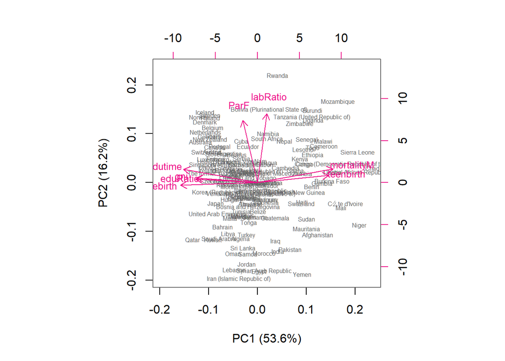

```r
pc_lab_std <- paste0(names(pca_pr), " (", pca_pr_std, "%)")
biplot(pca_human_std, cex = c(0.5, 0.8), col = c("grey40", "deeppink2"), xlab = pc_lab_std[1], ylab = pc_lab_std[2])
```

From the biplot, we can see that actually many variables are almost parallel to PC 1, including `edutime`, `eduRatio`, `teenbirth`, `dni`, `mortalityM` and `lifebirth`. The other two variables `ParF` and `labRatio` are almost paraelle to PC 2. We see that `dni` does not have determining power over all the data thanks to the standardization process.

> **Step 3.** Analysis of TEA data.

Loading the dataset from the package `FactoMineR` and explore the data briefly. The data has 300 observations and 36 variables. Most of the variables are factor variables with only the `age` variable as numeric.

```r
library(FactoMineR)
data(tea)
TEA_ <- tea
str(TEA_)
```

```
## 'data.frame':    300 obs. of  36 variables:
##  $ breakfast       : Factor w/ 2 levels "breakfast","Not.breakfast": 1 1 2 2 1 2 1 2 1 1 ...
##  $ tea.time        : Factor w/ 2 levels "Not.tea time",..: 1 1 2 1 1 1 2 2 2 1 ...
##  $ evening         : Factor w/ 2 levels "evening","Not.evening": 2 2 1 2 1 2 2 1 2 1 ...
##  $ lunch           : Factor w/ 2 levels "lunch","Not.lunch": 2 2 2 2 2 2 2 2 2 2 ...
##  $ dinner          : Factor w/ 2 levels "dinner","Not.dinner": 2 2 1 1 2 1 2 2 2 2 ...
##  $ always          : Factor w/ 2 levels "always","Not.always": 2 2 2 2 1 2 2 2 2 2 ...
##  $ home            : Factor w/ 2 levels "home","Not.home": 1 1 1 1 1 1 1 1 1 1 ...
##  $ work            : Factor w/ 2 levels "Not.work","work": 1 1 2 1 1 1 1 1 1 1 ...
##  $ tearoom         : Factor w/ 2 levels "Not.tearoom",..: 1 1 1 1 1 1 1 1 1 2 ...
##  $ friends         : Factor w/ 2 levels "friends","Not.friends": 2 2 1 2 2 2 1 2 2 2 ...
##  $ resto           : Factor w/ 2 levels "Not.resto","resto": 1 1 2 1 1 1 1 1 1 1 ...
##  $ pub             : Factor w/ 2 levels "Not.pub","pub": 1 1 1 1 1 1 1 1 1 1 ...
##  $ Tea             : Factor w/ 3 levels "black","Earl Grey",..: 1 1 2 2 2 2 2 1 2 1 ...
##  $ How             : Factor w/ 4 levels "alone","lemon",..: 1 3 1 1 1 1 1 3 3 1 ...
```

[output cut: 22 more lines]

```r
dim(TEA_)
```

```
## [1] 300  36
```

Here, we select a subset of the `tea` data set for analysis.

```r
kc <- c("Tea", "escape.exoticism", "spirituality", "healthy", "diuretic", "friendliness", "sophisticated", "slimming", "exciting", "relaxing", "effect.on.health")
tea_type_reason <- dplyr::select(TEA_, one_of(kc))
summary(tea_type_reason)
```

```
##         Tea                  escape.exoticism           spirituality
##  black    : 74   escape-exoticism    :142     Not.spirituality:206
##  Earl Grey:193   Not.escape-exoticism:158     spirituality    : 94
##  green    : 33
##         healthy            diuretic             friendliness
##  healthy    :210   diuretic    :174   friendliness    :242
##  Not.healthy: 90   Not.diuretic:126   Not.friendliness: 58
##
##            sophisticated        slimming          exciting
##  Not.sophisticated: 85   No.slimming:255   exciting   :116
##  sophisticated    :215   slimming   : 45   No.exciting:184
##
##         relaxing              effect.on.health
##  No.relaxing:113   effect on health   : 66
##  relaxing   :187   No.effect on health:234
##
```

```r
str(tea_type_reason)
```

```
## 'data.frame':    300 obs. of  11 variables:
##  $ Tea             : Factor w/ 3 levels "black","Earl Grey",..: 1 1 2 2 2 2 2 1 2 1 ...
##  $ escape.exoticism: Factor w/ 2 levels "escape-exoticism",..: 2 1 2 1 1 2 2 2 2 2 ...
##  $ spirituality    : Factor w/ 2 levels "Not.spirituality",..: 1 1 1 2 2 1 1 1 1 1 ...
##  $ healthy         : Factor w/ 2 levels "healthy","Not.healthy": 1 1 1 1 2 1 1 1 2 1 ...
##  $ diuretic        : Factor w/ 2 levels "diuretic","Not.diuretic": 2 1 1 2 1 2 2 2 2 1 ...
##  $ friendliness    : Factor w/ 2 levels "friendliness",..: 2 2 1 2 1 2 2 1 2 1 ...
##  $ sophisticated   : Factor w/ 2 levels "Not.sophisticated",..: 1 1 1 2 1 1 1 2 2 1 ...
##  $ slimming        : Factor w/ 2 levels "No.slimming",..: 1 1 1 1 1 1 1 1 1 1 ...
##  $ exciting        : Factor w/ 2 levels "exciting","No.exciting": 2 1 2 2 2 2 2 2 2 2 ...
##  $ relaxing        : Factor w/ 2 levels "No.relaxing",..: 1 1 2 2 2 2 2 2 2 2 ...
##  $ effect.on.health: Factor w/ 2 levels "effect on health",..: 2 2 2 2 2 2 2 2 2 2 ...
```

The selected data set is based on different tea types and different reasons for drinking tea. It is visualized here by bar plots.

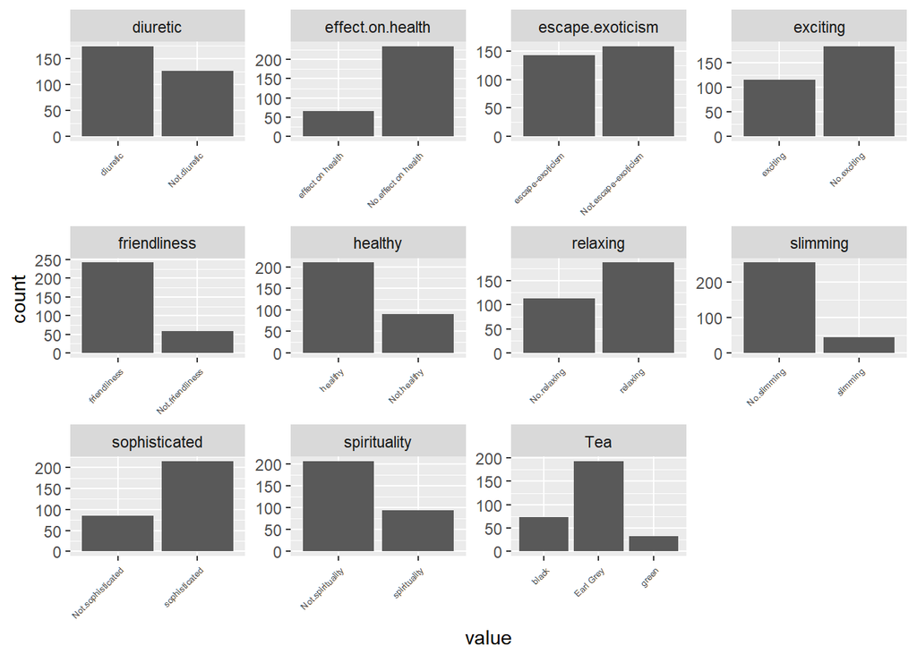

```r
gather(tea_type_reason) %>% ggplot(aes(value)) + facet_wrap("key", scales = "free") + geom_bar() + theme(axis.text.x = element_text(angle = 45, hjust = 1, size = 5))
```

The MCA of the selected data is conducted. The summary of the MCA is printed here:

```r
mca <- MCA(tea_type_reason, graph = FALSE)
summary(mca)
```

```
##
## Call:
## MCA(X = tea_type_reason, graph = FALSE)
##
##
## Eigenvalues
##                        Dim.1   Dim.2   Dim.3   Dim.4   Dim.5   Dim.6
## Variance               0.138   0.135   0.121   0.116   0.103   0.090
## % of var.             12.634  12.339  11.073  10.658   9.419   8.221
## Cumulative % of var.  12.634  24.973  36.045  46.703  56.122  64.342
##                        Dim.7   Dim.8   Dim.9  Dim.10  Dim.11  Dim.12
## Variance               0.080   0.077   0.066   0.062   0.055   0.049
## % of var.              7.325   7.017   6.066   5.687   5.057   4.506
## Cumulative % of var.  71.667  78.685  84.751  90.438  95.494 100.000
##
## Individuals (the 10 first)
##                         Dim.1    ctr   cos2    Dim.2    ctr   cos2
## 1                    |  0.637  0.982  0.285 | -0.550  0.750  0.213 |
## 2                    |  0.190  0.088  0.025 | -0.060  0.009  0.002 |
## 3                    |  0.055  0.007  0.004 | -0.482  0.575  0.339 |
## 4                    | -0.107  0.028  0.011 | -0.090  0.020  0.008 |
## 5                    |  0.007  0.000  0.000 |  0.153  0.058  0.023 |
## 6                    |  0.462  0.517  0.194 | -0.547  0.742  0.272 |
## 7                    |  0.462  0.517  0.194 | -0.547  0.742  0.272 |
## 8                    |  0.122  0.036  0.019 | -0.528  0.690  0.359 |
## 9                    |  0.528  0.674  0.258 | -0.129  0.041  0.015 |
## 10                   |  0.104  0.026  0.012 | -0.632  0.988  0.438 |
##                       Dim.3    ctr   cos2
## 1                     0.238  0.156  0.040 |
## 2                     0.586  0.948  0.234 |
## 3                    -0.066  0.012  0.006 |
## 4                    -0.495  0.675  0.226 |
## 5                    -0.388  0.416  0.146 |
## 6                    -0.189  0.098  0.032 |
## 7                    -0.189  0.098  0.032 |
## 8                    -0.306  0.259  0.121 |
## 9                    -0.323  0.287  0.096 |
## 10                   -0.027  0.002  0.001 |
##
## Categories (the 10 first)
```

[output cut: 20 more lines]

```
## Not.healthy           9.543 | -0.202  0.920  0.017 -2.285 |
## diuretic              0.568 |  0.354  5.470  0.173  7.193 |
##
## Categorical variables (eta2)
##                        Dim.1 Dim.2 Dim.3
## Tea                  | 0.009 0.159 0.244 |
## escape.exoticism     | 0.043 0.220 0.062 |
## spirituality         | 0.207 0.038 0.043 |
## healthy              | 0.303 0.305 0.017 |
## diuretic             | 0.246 0.001 0.173 |
## friendliness         | 0.068 0.006 0.022 |
## sophisticated        | 0.177 0.048 0.010 |
## slimming             | 0.279 0.041 0.006 |
## exciting             | 0.039 0.224 0.231 |
## relaxing             | 0.062 0.082 0.518 |
```

Next, the variable biplot of the MCA is drawn.

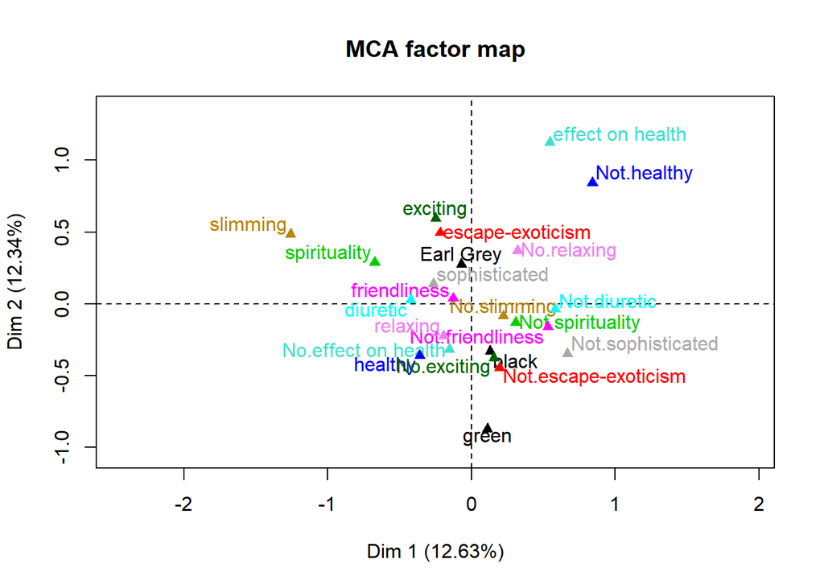

```r
plot(mca, invisible=c("ind"), habillage = "quali")
```

> **Concluding remarks.**

In this chapter, PCA and MCA analysis were covered. For data including multiple variables, it is often useful to reduce the variable dimensions so that the data can be plot and visualized easilier. The most useful methods are PCA and MCA, both of which effectively reduce the dimension.